# Session 3: NMDS and Ecological Ordination

Community composition, dissimilarity and environmental gradients

O Rodriguez de Rivera Ortega, PhD

University of Exeter

# 1 Session overview

## 1.1 What is this session about?

This session introduces **non-metric multidimensional scaling**, usually called **NMDS**.

NMDS is an ordination method commonly used in ecology to visualise differences in **community composition** among sites.

In this session, we use the `dune` dataset from the `vegan` package. The dataset contains vegetation community data from dune meadow sites.

The main question is:

> Do sites with different environmental or management conditions have different plant community composition?

Unlike PCA, which works directly with continuous variables and Euclidean distances, NMDS works from a **dissimilarity matrix**. This makes it especially useful for ecological community data, where we often have:

- many zeros;
- non-normal species abundance data;
- many species columns;
- interest in compositional differences among sites;
- nonlinear ecological gradients.

## 1.2 Learning outcomes

By the end of this section, students should be able to:

- describe a community matrix;
- explain why Bray-Curtis dissimilarity is commonly used in ecology;
- fit an NMDS ordination using `vegan::metaMDS()`;
- interpret NMDS stress;
- interpret ordination plots;
- overlay environmental variables;
- connect NMDS visualisation with PERMANOVA-style hypothesis testing.

# 2 NMDS in context

## 2.1 Continuity from PCA

PCA is useful when we have continuous variables and want to summarise the main axes of variation.

For example, with penguin measurements, PCA can summarise variation in body size and bill shape.

Ecological community data are different. A community dataset often has rows representing sites and columns representing species. Each value is an abundance, count, cover score or presence-absence value.

This type of data often contains many zeros because most species are absent from most sites.

For this reason, ecological ordination often focuses on **dissimilarity** between sites rather than correlation between variables.

## 2.2 PCA versus NMDS

| PCA | NMDS |
| --- | --- |
| Uses continuous variables directly | Uses a dissimilarity matrix |
| Usually based on Euclidean distance | Can use Bray-Curtis or other ecological distances |
| Assumes linear structure | Preserves rank order of dissimilarities |
| Works well for trait/environmental variables | Works well for community composition |
| Axes have direct mathematical meaning | Axes are arbitrary; distances matter more than axis values |

PCA asks:

> What are the main axes of variation in continuous variables?

NMDS asks:

> Which sites are similar or different in species composition?

# 3 Setup

## 3.1 Packages

```r
install.packages(c("tidyverse", "vegan"))
```

```r
library(tidyverse)
library(vegan)

theme_set(theme_minimal(base_size = 12))
```

# 4 Load the data

## 4.1 Dune community data

```r
data("dune", package = "vegan")
data("dune.env", package = "vegan")

dplyr::glimpse(dune)
```

```
## Rows: 20
## Columns: 30
## $ Achimill <dbl> 1, 3, 0, 0, 2, 2, 2, 0, 0, 4, 0, 0, 0, 0, 0, 0, 2, 0, 0, 0
## $ Agrostol <dbl> 0, 0, 4, 8, 0, 0, 0, 4, 3, 0, 0, 4, 5, 4, 4, 7, 0, 0, 0, 5
## $ Airaprae <dbl> 0, 0, 0, 0, 0, 0, 0, 0, 0, 0, 0, 0, 0, 0, 0, 0, 2, 0, 3, 0
## $ Alopgeni <dbl> 0, 2, 7, 2, 0, 0, 0, 5, 3, 0, 0, 8, 5, 0, 0, 4, 0, 0, 0, 0
## $ Anthodor <dbl> 0, 0, 0, 0, 4, 3, 2, 0, 0, 4, 0, 0, 0, 0, 0, 0, 4, 0, 4, 0
## $ Bellpere <dbl> 0, 3, 2, 2, 2, 0, 0, 0, 0, 2, 0, 0, 0, 0, 0, 0, 0, 2, 0, 0
## $ Bromhord <dbl> 0, 4, 0, 3, 2, 0, 2, 0, 0, 4, 0, 0, 0, 0, 0, 0, 0, 0, 0, 0
## $ Chenalbu <dbl> 0, 0, 0, 0, 0, 0, 0, 0, 0, 0, 0, 0, 1, 0, 0, 0, 0, 0, 0, 0
## $ Cirsarve <dbl> 0, 0, 0, 2, 0, 0, 0, 0, 0, 0, 0, 0, 0, 0, 0, 0, 0, 0, 0, 0
## $ Comapalu <dbl> 0, 0, 0, 0, 0, 0, 0, 0, 0, 0, 0, 0, 0, 2, 2, 0, 0, 0, 0, 0
## $ Eleopalu <dbl> 0, 0, 0, 0, 0, 0, 0, 4, 0, 0, 0, 0, 0, 4, 5, 8, 0, 0, 0, 4
## $ Elymrepe <dbl> 4, 4, 4, 4, 4, 0, 0, 0, 6, 0, 0, 0, 0, 0, 0, 0, 0, 0, 0, 0
## $ Empenigr <dbl> 0, 0, 0, 0, 0, 0, 0, 0, 0, 0, 0, 0, 0, 0, 0, 0, 0, 0, 2, 0
```

[output cut: 17 more lines]

```r
dplyr::glimpse(dune.env)
```

```
## Rows: 20
## Columns: 5
## $ A1         <dbl> 2.8, 3.5, 4.3, 4.2, 6.3, 4.3, 2.8, 4.2, 3.7, 3.3, 3.5, 5.8,…
## $ Moisture   <ord> 1, 1, 2, 2, 1, 1, 1, 5, 4, 2, 1, 4, 5, 5, 5, 5, 2, 1, 5, 5
## $ Management <fct> SF, BF, SF, SF, HF, HF, HF, HF, HF, BF, BF, SF, SF, NM, NM,…
## $ Use        <ord> Haypastu, Haypastu, Haypastu, Haypastu, Hayfield, Haypastu,…
## $ Manure     <ord> 4, 2, 4, 4, 2, 2, 3, 3, 1, 1, 1, 2, 3, 0, 0, 3, 0, 0, 0, 0
```

The object `dune` is a **site-by-species community matrix**.

- Rows are sites.
- Columns are plant species.
- Values are species abundances or cover scores.

The object `dune.env` contains environmental and management information for the same sites.

## 4.2 Inspect the first rows

```r
head(dune)
```

```
##   Achimill Agrostol Airaprae Alopgeni Anthodor Bellpere Bromhord Chenalbu
## 1        1        0        0        0        0        0        0        0
## 2        3        0        0        2        0        3        4        0
## 3        0        4        0        7        0        2        0        0
## 4        0        8        0        2        0        2        3        0
## 5        2        0        0        0        4        2        2        0
## 6        2        0        0        0        3        0        0        0
##   Cirsarve Comapalu Eleopalu Elymrepe Empenigr Hyporadi Juncarti Juncbufo
## 1        0        0        0        4        0        0        0        0
## 2        0        0        0        4        0        0        0        0
## 3        0        0        0        4        0        0        0        0
## 4        2        0        0        4        0        0        0        0
## 5        0        0        0        4        0        0        0        0
## 6        0        0        0        0        0        0        0        0
##   Lolipere Planlanc Poaprat Poatriv Ranuflam Rumeacet Sagiproc Salirepe
## 1        7        0       4       2        0        0        0        0
## 2        5        0       4       7        0        0        0        0
## 3        6        0       5       6        0        0        0        0
## 4        5        0       4       5        0        0        5        0
## 5        2        5       2       6        0        5        0        0
## 6        6        5       3       4        0        6        0        0
##   Scorautu Trifprat Trifrepe Vicilath Bracruta Callcusp
## 1        0        0        0        0        0        0
## 2        5        0        5        0        0        0
## 3        2        0        2        0        2        0
## 4        2        0        1        0        2        0
## 5        3        2        2        0        2        0
## 6        3        5        5        0        6        0
```

```r
head(dune.env)
```

```
##    A1 Moisture Management      Use Manure
## 1 2.8        1         SF Haypastu      4
## 2 3.5        1         BF Haypastu      2
## 3 4.3        2         SF Haypastu      4
## 4 4.2        2         SF Haypastu      4
## 5 6.3        1         HF Hayfield      2
## 6 4.3        1         HF Haypastu      2
```

The row order of `dune` and `dune.env` matches. This is important because the environmental data will later be joined to the NMDS site scores.

# 5 Community data

## 5.1 What is a community matrix?

A community matrix is a table where each row is a sampling unit, such as a site, plot or quadrat, and each column is a species.

A small example might look like this:

| Site | Species A | Species B | Species C |
| --- | --- | --- | --- |
| Site 1 | 4 | 0 | 2 |
| Site 2 | 0 | 7 | 1 |
| Site 3 | 2 | 1 | 0 |

The aim is usually to compare the whole species composition of sites, rather than analysing one species at a time.

## 5.2 Species richness by site

Species richness is the number of species present at a site. It is a useful summary, but it does not describe the full community composition.

Two sites can have the same richness but completely different species.

```r
site_summary <- dune %>%
  dplyr::mutate(
    site = dplyr::row_number(),
    richness = rowSums(. > 0),
    total_abundance = rowSums(.)
  ) %>%
  dplyr::bind_cols(dune.env)

site_summary %>%
  dplyr::select(site, Management, Use, richness, total_abundance) %>%
  head()
```

```
##   site Management      Use richness total_abundance
## 1    1         SF Haypastu        5              18
## 2    2         BF Haypastu       10              42
## 3    3         SF Haypastu       10              40
## 4    4         SF Haypastu       13              45
## 5    5         HF Hayfield       14              43
## 6    6         HF Haypastu       11              48
```

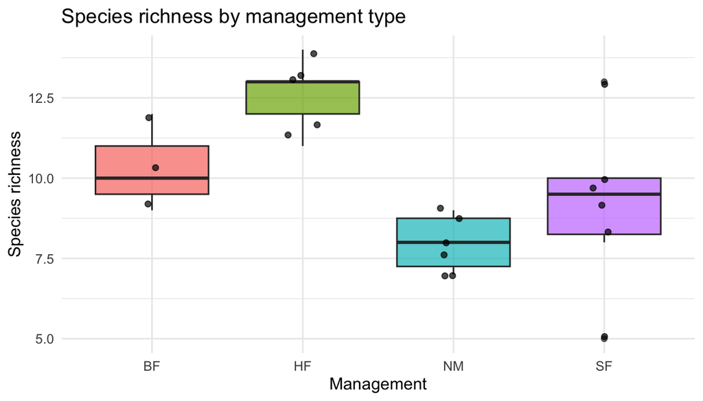

```r
ggplot(site_summary, aes(x = Management, y = richness, fill = Management)) +
  geom_boxplot(alpha = 0.7) +
  geom_jitter(width = 0.1, alpha = 0.7) +
  guides(fill = "none") +
  labs(
    title = "Species richness by management type",
    x = "Management",
    y = "Species richness"
  )
```

Richness is a univariate summary. NMDS uses the whole community matrix.

# 6 Bray-Curtis dissimilarity

## 6.1 Why use dissimilarity?

NMDS starts by calculating how different each pair of sites is.

For ecological community data, we often use **Bray-Curtis dissimilarity** because it works well with abundance data and many zeros.

Bray-Curtis dissimilarity ranges from 0 to 1:

- 0 means two sites have identical composition;
- values closer to 1 mean two sites are very different.

```r
bray_dist <- vegan::vegdist(dune, method = "bray")

as.matrix(bray_dist)[1:5, 1:5]
```

```
##           1         2         3         4         5
## 1 0.0000000 0.4666667 0.4482759 0.5238095 0.6393443
## 2 0.4666667 0.0000000 0.3414634 0.3563218 0.4117647
## 3 0.4482759 0.3414634 0.0000000 0.2705882 0.4698795
## 4 0.5238095 0.3563218 0.2705882 0.0000000 0.5000000
## 5 0.6393443 0.4117647 0.4698795 0.5000000 0.0000000
```

## 6.2 Interpreting the distance matrix

The distance matrix contains pairwise dissimilarities between sites.

For example, the value in row 1 and column 2 is the Bray-Curtis dissimilarity between site 1 and site 2.

NMDS tries to place the sites in a low-dimensional plot so that sites with small dissimilarities are close together and sites with large dissimilarities are far apart.

# 7 Fit NMDS

## 7.1 Run NMDS

```r
set.seed(123)

nmds_fit <- vegan::metaMDS(
  dune,
  distance = "bray",
  k = 2,
  trymax = 100,
  autotransform = FALSE
)
```

```
## *** Best solution repeated 3 times
```

```r
nmds_fit
```

```
##
## Call:
## vegan::metaMDS(comm = dune, distance = "bray", k = 2, trymax = 100,      autotransform = FALSE)
##
## global Multidimensional Scaling using monoMDS
##
## Data:     dune
## Distance: bray
##
## Dimensions: 2
## Stress:     0.1183186
## Stress type 1, weak ties
## Best solution was repeated 3 times in 20 tries
## The best solution was from try 18 (random start)
## Scaling: centring, PC rotation, halfchange scaling
## Species: expanded scores based on 'dune'
```

The argument `k = 2` asks for a two-dimensional ordination.

The argument `trymax = 100` allows the algorithm to try several random starts. This is useful because NMDS is an iterative method and can converge to different solutions.

The argument `autotransform = FALSE` keeps the data transformation explicit. In teaching, this is helpful because students can see exactly what has been done.

# 8 Stress

## 8.1 What is stress?

Stress measures how well the low-dimensional NMDS plot preserves the rank order of the original dissimilarities.

Lower stress is better.

Rules of thumb:

| Stress | Interpretation |
| --- | --- |
| < 0.05 | Excellent representation |
| < 0.10 | Good representation |
| < 0.20 | Usable, but interpret with caution |
| > 0.20 | Poor representation; interpret very carefully |

These are only guidelines. Ecological interpretation should also consider the dataset, sample size and scientific question.

## 8.2 Stress plot

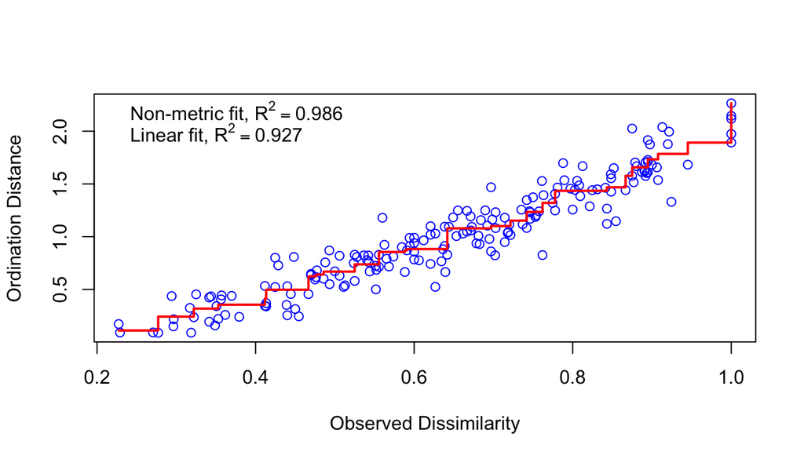

```r
vegan::stressplot(nmds_fit)
```

The stress plot compares observed dissimilarities with distances in the ordination. A clearer monotonic relationship indicates that the NMDS representation is working reasonably well.

# 9 Plot the ordination

## 9.1 Extract site scores

```r
site_scores <- vegan::scores(nmds_fit, display = "sites") %>%
  as.data.frame() %>%
  tibble::rownames_to_column("site") %>%
  tibble::as_tibble() %>%
  dplyr::bind_cols(dune.env)

head(site_scores)
```

```
## # A tibble: 6 × 8
##   site    NMDS1   NMDS2    A1 Moisture Management Use      Manure
##   <chr>   <dbl>   <dbl> <dbl> <ord>    <fct>      <ord>    <ord>
## 1 1     -0.841  -0.716    2.8 1        SF         Haypastu 4
## 2 2     -0.505  -0.409    3.5 1        BF         Haypastu 2
## 3 3     -0.0827 -0.437    4.3 2        SF         Haypastu 4
## 4 4     -0.116  -0.522    4.2 2        SF         Haypastu 4
## 5 5     -0.627  -0.0867   6.3 1        HF         Hayfield 2
## 6 6     -0.543   0.113    4.3 1        HF         Haypastu 2
```

The site scores are the coordinates of each site in the NMDS plot.

The axes `NMDS1` and `NMDS2` do not have direct ecological units. The important information is the relative distance among sites.

## 9.2 Plot sites in NMDS space

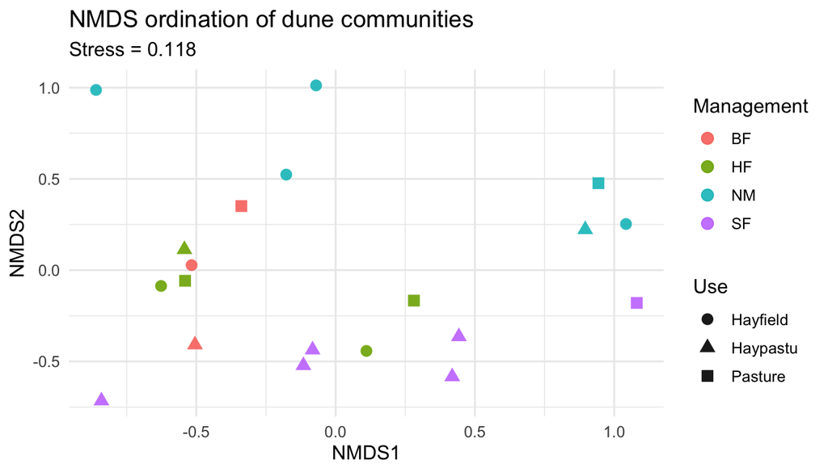

```r
ggplot(site_scores, aes(x = NMDS1, y = NMDS2, colour = Management, shape = Use)) +
  geom_point(size = 3, alpha = 0.9) +
  labs(
    title = "NMDS ordination of dune communities",
    subtitle = paste("Stress =", round(nmds_fit$stress, 3)),
    x = "NMDS1",
    y = "NMDS2",
    colour = "Management",
    shape = "Use"
  )
```

## 9.3 Interpreting the NMDS plot

Nearby points represent sites with similar plant community composition.

Distant points represent sites with more different community composition.

If sites with the same management type cluster together, this suggests that management may be associated with differences in plant community composition.

However, NMDS itself is a visualisation method. To test hypotheses formally, we need additional methods such as PERMANOVA.

# 10 Species scores

## 10.1 Extract species scores

```r
species_scores <- vegan::scores(nmds_fit, display = "species") %>%
  as.data.frame() %>%
  tibble::rownames_to_column("species") %>%
  tibble::as_tibble()

head(species_scores)
```

```
## # A tibble: 6 × 3
##   species   NMDS1   NMDS2
##   <chr>     <dbl>   <dbl>
## 1 Achimill -0.823  0.0433
## 2 Agrostol  0.711 -0.289
## 3 Airaprae -0.528  1.68
## 4 Alopgeni  0.391 -0.586
## 5 Anthodor -0.720  0.659
## 6 Bellpere -0.478 -0.244
```

Species scores show where species are located in the ordination space.

Species labels close to a set of sites tend to be associated with those sites. However, species scores should be interpreted carefully because NMDS is primarily based on site dissimilarities.

## 10.2 Plot sites and species

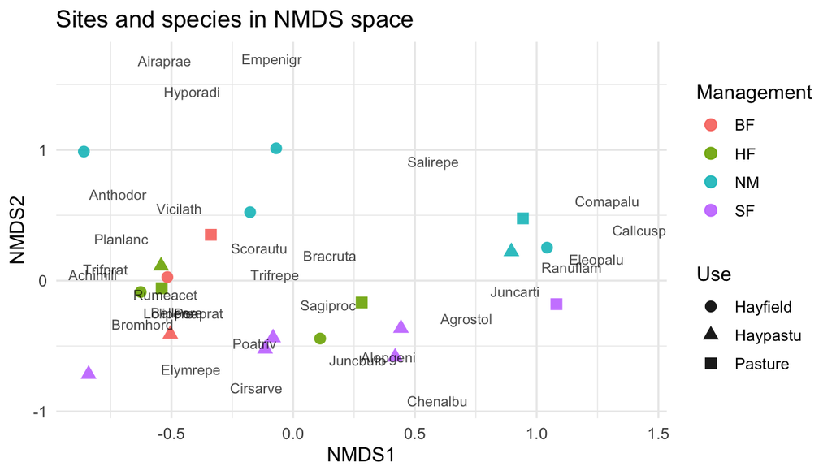

```r
ggplot(site_scores, aes(x = NMDS1, y = NMDS2)) +
  geom_point(aes(colour = Management, shape = Use), size = 3, alpha = 0.9) +
  geom_text(
    data = species_scores,
    aes(x = NMDS1, y = NMDS2, label = species),
    inherit.aes = FALSE,
    size = 3,
    alpha = 0.7
  ) +
  labs(
    title = "Sites and species in NMDS space",
    x = "NMDS1",
    y = "NMDS2",
    colour = "Management",
    shape = "Use"
  )
```

# 11 Environmental overlays

## 11.1 Why overlay environmental variables?

After fitting the NMDS, we may want to ask whether environmental variables are related to the ordination.

For example:

- Are drier sites located in one part of the ordination?
- Are fertilised sites compositionally different from unfertilised sites?
- Does management explain the main separation among sites?

The function `envfit()` relates environmental variables to the ordination after the ordination has been fitted.

## 11.2 Fit environmental vectors

```r
set.seed(123)

env_fit <- vegan::envfit(
  nmds_fit,
  dune.env,
  permutations = 999
)

env_fit
```

```
##
## ***VECTORS
##
##      NMDS1   NMDS2     r2 Pr(>r)
## A1 0.96474 0.26322 0.3649  0.014 *
## ---
## Signif. codes:  0 '***' 0.001 '**' 0.01 '*' 0.05 '.' 0.1 ' ' 1
## Permutation: free
## Number of permutations: 999
##
## ***FACTORS:
##
## Centroids:
##                NMDS1   NMDS2
## Moisture1    -0.5101 -0.0403
## Moisture2    -0.3938  0.0139
## Moisture4     0.2765 -0.4033
## Moisture5     0.6561  0.1476
## ManagementBF -0.4534 -0.0102
## ManagementHF -0.2636 -0.1282
## ManagementNM  0.2958  0.5790
## ManagementSF  0.1506 -0.4670
## UseHayfield  -0.1568  0.3248
## UseHaypastu  -0.0412 -0.3370
## UsePasture    0.2854  0.0844
## Manure0       0.2958  0.5790
## Manure1      -0.2482 -0.0215
## Manure2      -0.3079 -0.1866
## Manure3       0.3101 -0.2470
## Manure4      -0.3463 -0.5583
##
## Goodness of fit:
##                r2 Pr(>r)
## Moisture   0.5014  0.003 **
## Management 0.4134  0.004 **
## Use        0.1871  0.131
## Manure     0.4247  0.023 *
## ---
## Signif. codes:  0 '***' 0.001 '**' 0.01 '*' 0.05 '.' 0.1 ' ' 1
## Permutation: free
## Number of permutations: 999
```

The output gives information about how environmental variables relate to the ordination.

For continuous variables, `envfit()` estimates vectors. For factors, it estimates group centroids.

Small p-values suggest that an environmental variable is related to the ordination structure.

## 11.3 Plot environmental fit using base plotting

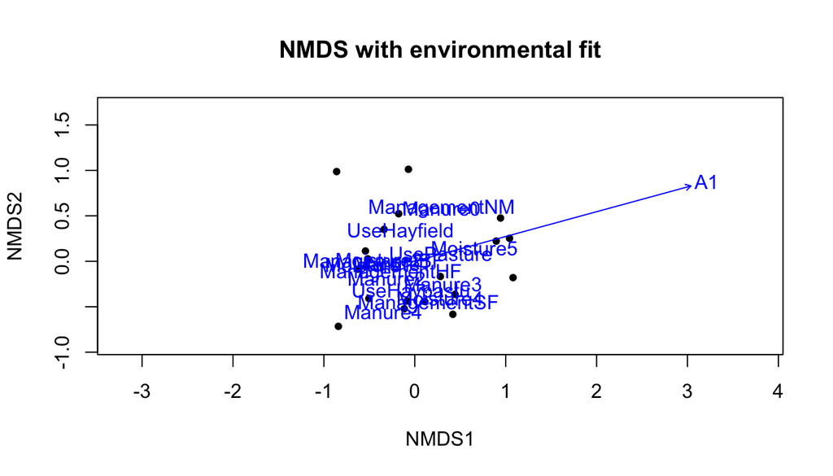

```r
plot(nmds_fit, type = "n", main = "NMDS with environmental fit")
points(nmds_fit, display = "sites", pch = 19)
plot(env_fit, add = TRUE)
```

This plot adds environmental information to the ordination. It is useful as a quick diagnostic and teaching plot.

# 12 PERMANOVA as a modelling bridge

## 12.1 What is PERMANOVA?

PERMANOVA tests whether community composition differs among groups or along environmental gradients using a dissimilarity matrix.

It is implemented in `vegan` using `adonis2()`.

This connects back to the modelling sessions. We are still asking whether predictors explain variation in a response, but now the response is multivariate community composition.

## 12.2 PERMANOVA with management and use

```r
vegan::adonis2(
  dune ~ Management + Use,
  data = dune.env,
  method = "bray"
)
```

```
## Permutation test for adonis under reduced model
## Permutation: free
## Number of permutations: 999
##
## vegan::adonis2(formula = dune ~ Management + Use, data = dune.env, method = "bray")
##          Df SumOfSqs      R2      F Pr(>F)
## Model     5   1.8443 0.42901 2.1038  0.007 **
## Residual 14   2.4547 0.57099
## Total    19   4.2990 1.00000
## ---
## Signif. codes:  0 '***' 0.001 '**' 0.01 '*' 0.05 '.' 0.1 ' ' 1
```

## 12.3 Interpreting PERMANOVA

The p-value asks whether the observed association is stronger than expected under permutation.

PERMANOVA does not replace the NMDS plot. Instead, the NMDS plot provides visual interpretation, while PERMANOVA gives a formal test.

# 13 Practical exercise

## 13.1 Exercise: change the ecological question

1. Re-run the NMDS using `k = 3`. Does stress improve?
2. Colour the site plot by `Moisture` instead of `Management`.
3. Run a PERMANOVA model with `Moisture` and `Manure`.
4. Which environmental variable seems most related to community composition?

```r
set.seed(123)

nmds_3d <- vegan::metaMDS(
  dune,
  distance = "bray",
  k = 3,
  trymax = 100,
  autotransform = FALSE
)

nmds_3d$stress

site_scores %>%
  ggplot(aes(x = NMDS1, y = NMDS2, colour = Moisture)) +
  geom_point(size = 3)

vegan::adonis2(
  dune ~ Moisture + Manure,
  data = dune.env,
  method = "bray"
)
```

# 14 Exercise solution

## 14.4 4. Which environmental variable seems most related to community composition?

Look at the PERMANOVA table.

The most important variable is usually the one with:

- the larger (R^2);
- the smaller p-value;
- a pattern that also makes sense in the NMDS plot.

# 15 Session wrap-up

So far in Session 3:

- PCA reduced continuous traits to main axes of variation.
- Clustering found unsupervised groups.
- LDA used known labels for classification.
- NMDS visualised ecological community composition.

These methods are all ordination or multivariate tools, but they answer different scientific questions.

| Method | Main question |
| --- | --- |
| PCA | What are the main axes of variation in continuous variables? |
| Clustering | Do observations naturally group together? |
| LDA | Can known groups be predicted from multivariate traits? |
| NMDS | Which sites are similar in community composition? |

# 16 Transition to optional topics

The optional files extend the same logic to other multivariate data types.

Exploratory factor analysis is useful when observed variables are thought to reflect a smaller number of latent constructs.

Cumulative link mixed models are useful when the response is ordinal, such as ratings from 1 to 5.

Together, these methods show how multivariate thinking changes depending on the response type, data structure and scientific question.